# Elecciones 2011 - Análisis votos en blanco

```r
knitr::opts_chunk$set(fig.width = 8, fig.height = 8)
source("functions.R")
library(ggplot2)
theme_set(theme_bw(16))
# Read raw data
file_path <- "~/Dropbox/data/elecciones20112015/04_201105_1_sheet1.csv"
elections <- readRawData(file_path)
# Processed data, saved by processElectionData.R
load("~/Dropbox/data/elecciones20112015/elections2011_processed.Rda")
```

Hay 8083 localidades en total. Por curiosidad, ¿cómo se reparte esto en términos de población?

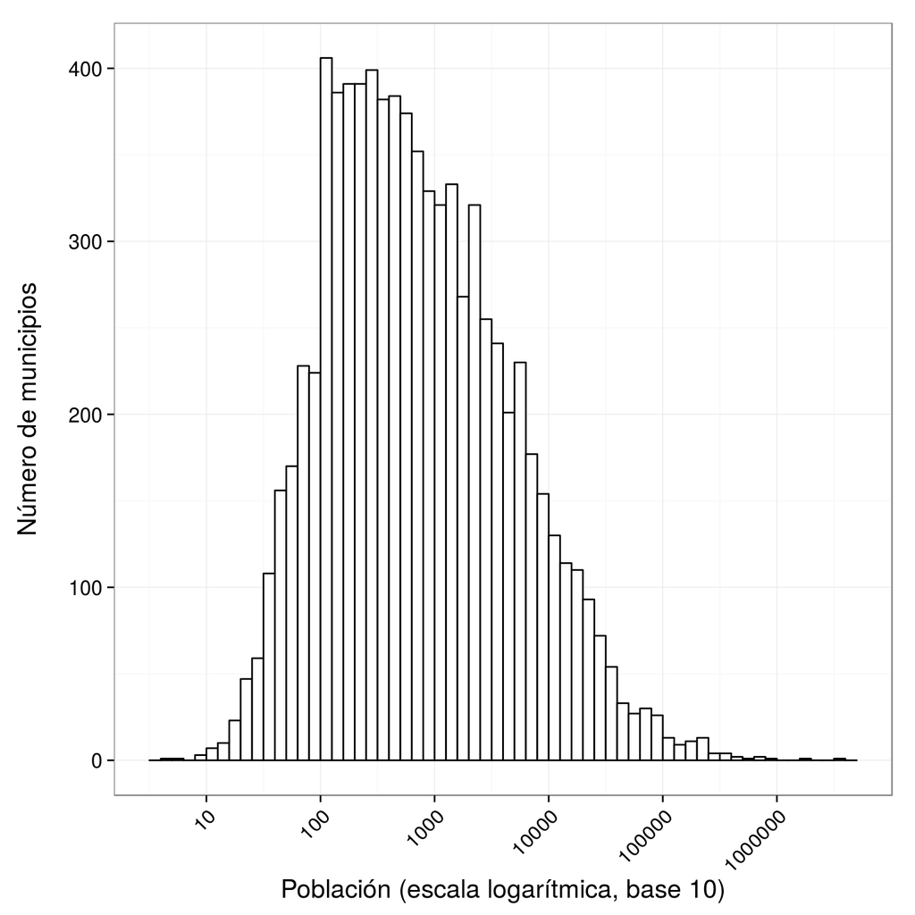

```r
ggplot(elections) + geom_histogram(aes(x = Población), fill = "white",
                                   color = "black", binwidth = 1 / 10) +
    scale_x_log10(breaks = 10 ^ (1:6),
                  labels = c(as.character(10 ^ (1:4)),
                             "100000", "1000000")) +
    xlab("Población (escala logarítmica, base 10)") +
    ylab("Número de municipios\n") +
    theme(axis.text.x = element_text(angle = 45, hjust = 1))
```

En general, ¿cuánto voto en blanco hay?

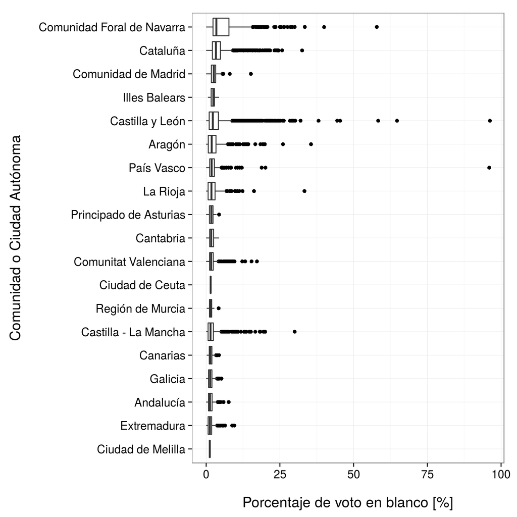

```r
elections$voto_blanco_p <- with(elections,
                                (Votos.en.blanco / Votos.válidos) * 100)

# Create a new ordered factor, plot looks better
elections$comunidad_blanco <- reorder(elections$Nombre.de.Comunidad,
                                      elections$voto_blanco_p,
                                      median)

ggplot(elections) + geom_boxplot((aes(x = comunidad_blanco,
                                      y = voto_blanco_p))) +
    coord_flip() + xlab("Comunidad o Ciudad Autónoma\n") +
    ylab("\nPorcentaje de voto en blanco [%]")
```

En general se vota poco en blanco (de media, un 2.8477), pero hay municipios pequeños en los que está a la orden del día:

```r
elections[order(-elections$voto_blanco_p), c("Nombre.de.Municipio",
                                             #"Nombre.de.Comunidad",
                                             "voto_blanco_p",
                                             "Población")][1:20, ]
```

```
##            Nombre.de.Municipio voto_blanco_p Población
## 3292              Torregalindo         96.20       143
## 7122                     Aduna         95.99       429
## 4471                     Rello         64.71        25
## 3021           Arauzo de Torre         58.33        91
## 6973               Mendigorría         57.84      1076
## 4418        Estepa de San Juan         45.45         9
## 4400      Centenera de Andaluz         44.44        24
## 6852                  Arellano         40.00       200
## 3123                   Hacinas         38.10       185
## 1433       Salvatierra de Esca         35.56       235
## 6940               Isaba/Izaba         33.46       492
## 7513             Torremontalbo         33.33        15
## 5643          Lles de Cerdanya         32.54       268
## 3321                    Vileña         32.00        34
## 3177 Monterrubio de la Demanda         30.19        71
## 2333               Cincovillas         30.00        25
## 7005         Petilla de Aragón         30.00        23
## 4292                 Sangarcía         29.66       429
## 3149 Junta de Villalba de Losa         29.31       114
## 6866                   Bakaiku         29.14       340
```

Ya que estamos, lo mismo se puede hacer para el voto nulo:

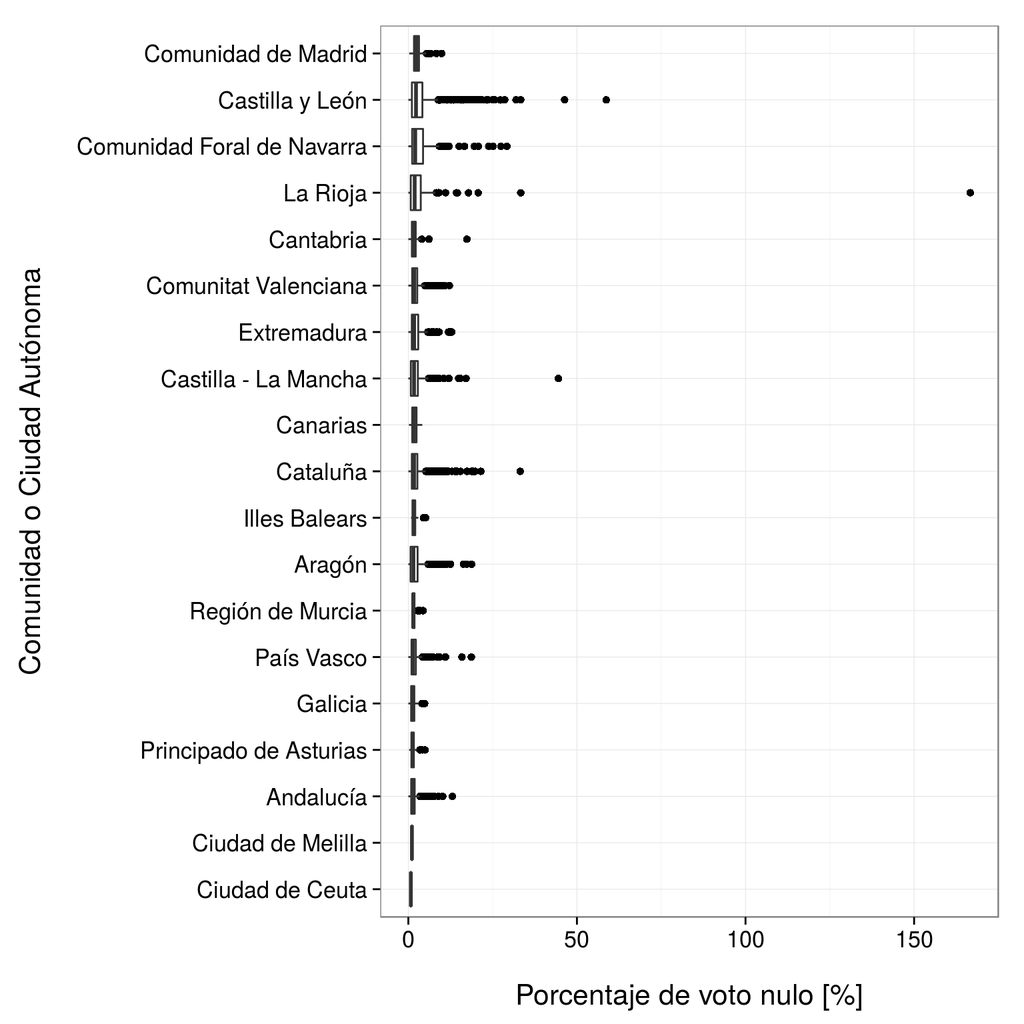

```r
elections$voto_nulo_p <- with(elections,
                                (Votos.nulos / Votos.válidos) * 100)

# Create a new ordered factor, plot looks better
elections$comunidad_nulo <- reorder(elections$Nombre.de.Comunidad,
                                      elections$voto_nulo_p,
                                      median)

ggplot(elections) + geom_boxplot((aes(x = comunidad_nulo,
                                      y = voto_nulo_p))) +
    coord_flip() + xlab("Comunidad o Ciudad Autónoma\n") +
    ylab("\nPorcentaje de voto nulo [%]")
```

Ese pueblo de La Rioja es Valdemadera, donde [votaron 8 personas](http://elecciones.lainformacion.com/municipales/2011/la-rioja/la-rioja/valdemadera.html) de 9 censadas y hubo 5 votos nulos.

El código para la función que calcula D’Hont no tiene en cuenta estas situaciones anómalas y realmente no sé cómo se procede al cálculo de concejales en estos casos. Además, en localidades de menos de 250 habitantes el sistema es ligeramente diferente (gracias, [Prosikito](https://twitter.com/prosikito8/status/600325850509217792)) y el archivo de Excel tiene otra hoja con datos para estos municipios. **De aquí en adelante, utilizaré únicamente datos de municipios con más de 250 habitantes**.

```r
elections <- elections[elections$Población > 250, ]
election_processed <- election_processed[election_processed$town %in% elections$Nombre.de.Municipio,]
```

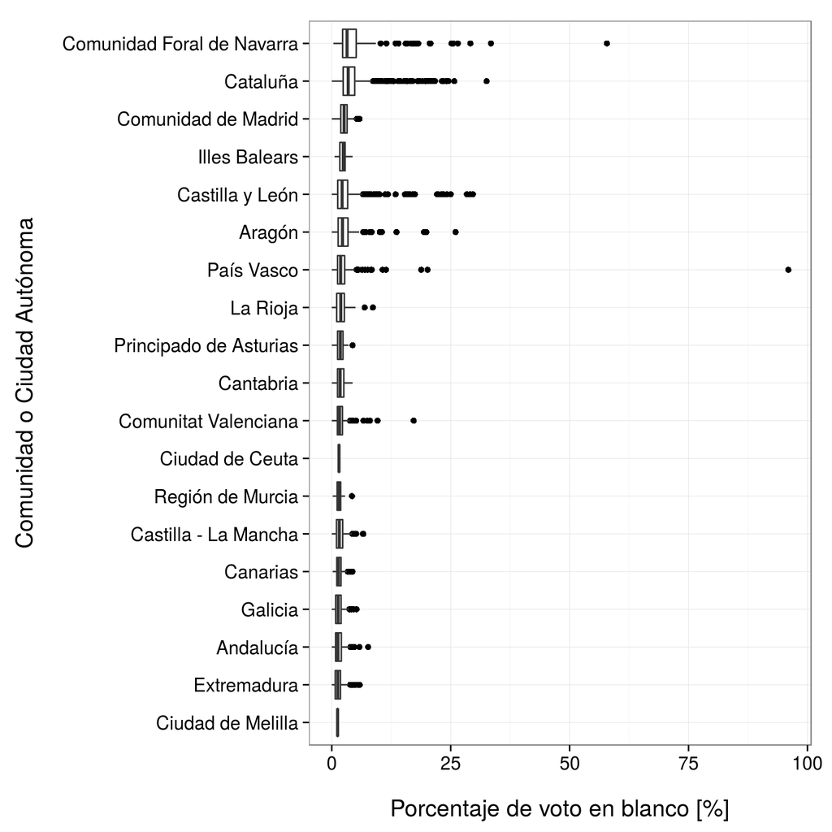

```r
ggplot(elections) + geom_boxplot((aes(x = comunidad_blanco,
                                      y = voto_blanco_p))) +
    coord_flip() + xlab("Comunidad o Ciudad Autónoma\n") +
    ylab("\nPorcentaje de voto en blanco [%]")
```

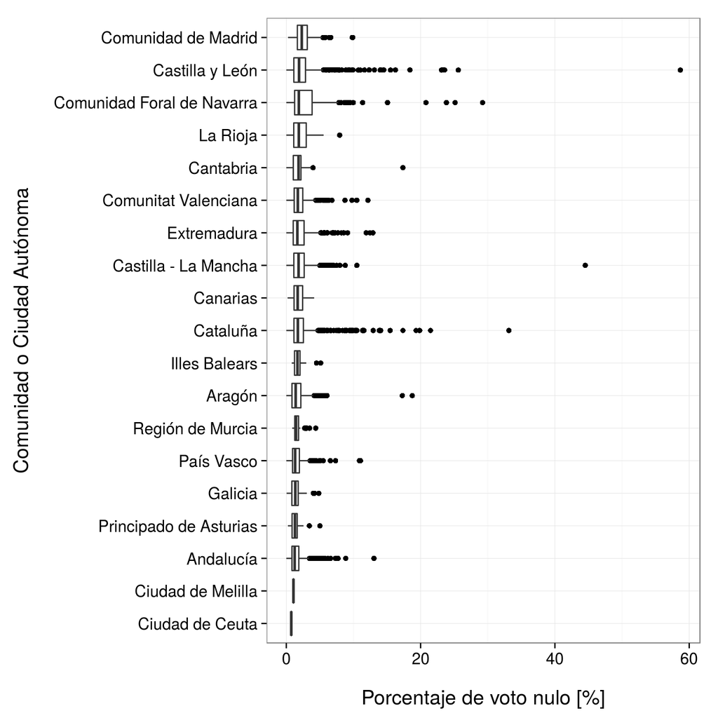

```r
ggplot(elections) + geom_boxplot((aes(x = comunidad_nulo,
                                      y = voto_nulo_p))) +
    coord_flip() + xlab("Comunidad o Ciudad Autónoma\n") +
    ylab("\nPorcentaje de voto nulo [%]")
```

¿Cuántas mayorías absolutas se repartieron por España?

```r
election_processed$local <- paste(election_processed$town, election_processed$province)
absol <- by(election_processed[,  c("party", "seats", "method", "town", "province")],
            election_processed$local,
            function(x) {
                # Current government, who and what condition
                cur <- x[x$method == "current", ]
                current_government <- cur$party[1]
                current_seats <- cur$seats[1]
                current_maj <- cur$seats[1] > sum(cur$seats[-1])

                # Without considering blanks
                bla <- x[x$method == "noblanks", ]
                blanks_government <- bla$party[1]
                blanks_seats <- bla$seats[1]
                blanks_maj <- bla$seats[1] > sum(bla$seats[-1])

                # Without threshold
                thr <- x[x$method == "nothreshold", ]
                threshold_government <- thr$party[1]
                threshold_seats <- thr$seats[1]
                threshold_maj <- thr$seats[1] > sum(thr$seats[-1])

                # Look for changes in seats
                current_blank <- nrow(cur) != nrow(bla) ||
                                 any(cur$seats != bla$seats)

                current_threshold <- nrow(cur) != nrow(thr) ||
                                     any(cur$seats != thr$seats)

                return(data.frame(town = unique(x$town),
                                  province = unique(x$province),
                                  current_government = current_government,
                                  current_seats = current_seats,
                                  current_maj = current_maj,
                                  blanks_government = blanks_government,
                                  blanks_seats = blanks_seats,
                                  blanks_maj = blanks_maj,
                                  threshold_government = threshold_government,
                                  threshold_seats = threshold_seats,
                                  threshold_maj = threshold_maj,
                                  current_blank = current_blank,
                                  current_threshold = current_threshold))

            })

absol <- do.call(rbind, absol)
absol$town <- as.character(absol$town)
```

¿En cuántos municipios cambiaría el número de concejales del partido en la mayoría? Pocos. Tabla debajo:

```r
sum(absol$current_seats != absol$blanks_seats)
```

```
## [1] 12
```

```r
absol[which(absol$current_seats != absol$blanks_seats), "town"]
```

```
##  [1] "Camargo"                  "Carlota (La)"
##  [3] "Castellbisbal"            "Hondarribia"
##  [5] "Maó"                      "Mollet del Vallès"
##  [7] "Montgat"                  "Orotava (La)"
##  [9] "Palau-solità i Plegamans" "Sant Cugat del Vallès"
## [11] "Sitges"                   "Soria"
```

```r
election_processed[election_processed$town %in% absol[which(absol$current_seats != absol$blanks_seats), "town"] & election_processed$method %in% c("current", "noblanks"), c("party", "seats", "method", "town")]
```

```
##                      party seats   method                     town
## 1416              P.S.O.E.    10  current             Carlota (La)
## 1417                  P.P.     6  current             Carlota (La)
## 1418                  I.U.     1  current             Carlota (La)
## 1419              P.S.O.E.     9 noblanks             Carlota (La)
## 1420                  P.P.     6 noblanks             Carlota (La)
## 1421      Iniciativa.C..I.     1 noblanks             Carlota (La)
## 1422                  I.U.     1 noblanks             Carlota (La)
## 13454                 P.P.    13  current                      Maó
## 13455             P.S.O.E.     8  current                      Maó
## 13456                 P.P.    12 noblanks                      Maó
## 13457             P.S.O.E.     8 noblanks                      Maó
## 13458                 I.U.     1 noblanks                      Maó
## 14599           CC.PNC.CCN    13  current             Orotava (La)
## 14600                 P.P.     3  current             Orotava (La)
```

[output cut: 102 more lines]

Solamente en un 1 caso una localidad dejaría de tener un gobierno con mayoría absoluta. Y el agraciado es:

```r
absol[absol$current_maj != absol$blanks_maj, "town"]
```

```
## [1] "Camargo"
```

Esto es solamente en casos en los que es el partido más votado el que pierde un concejal. Si echamos un ojo a cualquier partido con representación, hay movimientos de concejales en 29 localidades:

```r
table(absol$current_blank)
```

```
##
## FALSE  TRUE
##  5455    29
```

```r
absol[absol$current_blank, "town"]
```

```
##  [1] "Almansa"                    "Andoain"
##  [3] "Antigua"                    "Arcos de la Frontera"
##  [5] "Benetússer"                 "Camargo"
##  [7] "Cambrils"                   "Carlota (La)"
##  [9] "Castellbisbal"              "Corbera de Llobregat"
## [11] "Cornellà de Llobregat"      "Girona"
## [13] "Hondarribia"                "Las Palmas de Gran Canaria"
## [15] "Maó"                        "Meco"
## [17] "Mollet del Vallès"          "Montgat"
## [19] "Orotava (La)"               "Palau-solità i Plegamans"
## [21] "Ponferrada"                 "Prat de Llobregat (El)"
## [23] "Reus"                       "Rosario (El)"
## [25] "Sant Cugat del Vallès"      "Siero"
## [27] "Sitges"                     "Soria"
## [29] "Tàrrega"
```

```r
election_processed[election_processed$town %in% absol[absol$current_blank, "town"] & election_processed$method %in% c("current", "noblanks"), c("party", "seats", "method", "town")]
```

```
##                      party seats   method                       town
## 824                A.I.PRO     7  current       Arcos de la Frontera
## 825                   P.P.     7  current       Arcos de la Frontera
## 826               P.S.O.E.     7  current       Arcos de la Frontera
## 827                A.I.PRO     7 noblanks       Arcos de la Frontera
## 828                   P.P.     7 noblanks       Arcos de la Frontera
## 829               P.S.O.E.     6 noblanks       Arcos de la Frontera
## 830          PARTIDO.VEN.T     1 noblanks       Arcos de la Frontera
## 1416              P.S.O.E.    10  current               Carlota (La)
## 1417                  P.P.     6  current               Carlota (La)
## 1418                  I.U.     1  current               Carlota (La)
## 1419              P.S.O.E.     9 noblanks               Carlota (La)
## 1420                  P.P.     6 noblanks               Carlota (La)
## 1421      Iniciativa.C..I.     1 noblanks               Carlota (La)
## 1422                  I.U.     1 noblanks               Carlota (La)
```

[output cut: 278 more lines]

¿Cómo son estas ciudades?

```r
changed_towns <- absol[absol$current_blank, "town"]
elections_changed <- elections[elections$Nombre.de.Municipio %in% changed_towns, ]
mean(elections_changed$Población)
```

```
## [1] 48955
```

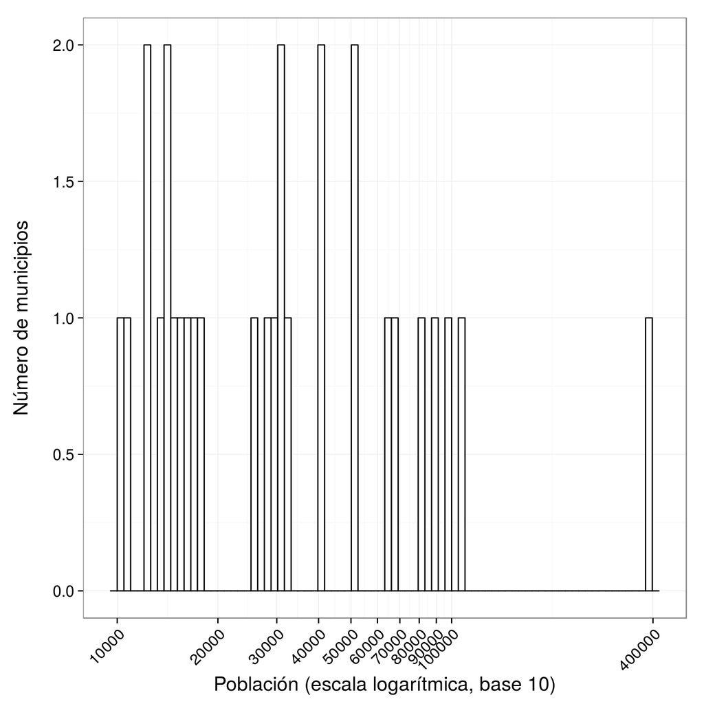

```r
ggplot(elections_changed) + geom_histogram(aes(x = Población), fill = "white",
                                   color = "black", binwidth = 1 / 50) +
    scale_x_log10(breaks = c(seq(10000, 100000, 10000), 4e5),
                  labels = c(as.character(seq(10000, 90000, 10000)), "100000",
                             "400000")) +
    xlab("Población (escala logarítmica, base 10)") +
    ylab("Número de municipios\n") +
    theme(axis.text.x = element_text(angle = 45, hjust = 1))
```

Son sitios más o menos grandecitos, de unos 50.000 habitantes de media; el mayor de ellos: Las Palmas de Gran Canaria. Tiene sentido: el umbral del 5 % hace efecto después de que se hayan hecho unos pocos repartos mediante D’Hont.

Todo esto tiene en cuenta un efecto muy poco realista pero posible con la ley actual: que no haya voto en blanco o éste se minimice lo máximo posible. Si atendemos a otros escenarios hipotéticos, como que no exista un umbral de voto mínimo para acceder al reparto de concejales, el cuento cambia bastante.

En ese caso, en todas estas localidades, anteriormente gobernadas por mayoría absoluta, hay que empezar a hacer pactos:

```r
absol[absol$current_maj != absol$threshold_maj & !absol$threshold_maj, "town"]
```

```
##  [1] "Alcalá de Guadaíra"           "Alfafar"
##  [3] "Algemesí"                     "Amposta"
##  [5] "Antequera"                    "Berga"
##  [7] "Camargo"                      "Coín"
##  [9] "Cuenca"                       "Ferrol"
## [11] "Gandia"                       "Inca"
## [13] "Lleida"                       "Manacor"
## [15] "Santiago de Compostela"       "Villajoyosa/Vila Joiosa (La)"
```

Y éste es el listado de movimientos total:

```r
t1 <- election_processed[election_processed$town %in% absol[absol$current_threshold, "town"] & election_processed$method %in% c("current", "nothreshold"), c("party", "seats", "method", "town")]
# Remove long names
t1$town <- ifelse(grepl("/", t1$town),
                  strsplit(t1$town, "/", fixed = TRUE)[[1]],
                  t1$town)
# Long party names
t1$party <- strtrim(t1$party, 15)
t1
```

```
##                 party seats      method                        town
## 73               P.P.    18     current                     Almería
## 74           P.S.O.E.     7     current                     Almería
## 75               I.U.     2     current                     Almería
## 79               P.P.    17 nothreshold                     Almería
## 80           P.S.O.E.     7 nothreshold                     Almería
## 81               I.U.     2 nothreshold                     Almería
## 82               UPyD     1 nothreshold                     Almería
## 824           A.I.PRO     7     current        Arcos de la Frontera
## 825              P.P.     7     current        Arcos de la Frontera
## 826          P.S.O.E.     7     current        Arcos de la Frontera
## 831           A.I.PRO     7 nothreshold        Arcos de la Frontera
## 832              P.P.     7 nothreshold        Arcos de la Frontera
## 833          P.S.O.E.     6 nothreshold        Arcos de la Frontera
## 834     PARTIDO.VEN.T     1 nothreshold        Arcos de la Frontera
```

[output cut: 1640 more lines]